# Activity 1.2: De novo Assembly of Bacterial Genomes

Laura M. Carroll

4/15/2019

# 1 Introduction

**Goal:** Assemble a bacterial genome *de novo* from Illumina short reads

**Input:** Trimmed Illumina paired-end reads in gzipped fastq format (*_trimmedP_1.fastq.gz and *_trimmedP_2.fastq.gz)

**Output:** Contigs and/or scaffolds in fasta format (*.fasta)

**Programs Used:**

- [SPAdes](http://cab.spbu.ru/software/spades/): a *de novo* assembler for bacterial genomes
- [QUAST](http://quast.sourceforge.net/quast): quality assessment tool for genome assemblies
- tmux: a terminal multiplexer
- [BWA](https://github.com/lh3/bwa) (optional; only used for the Supplemental Activity): a software package for mapping low-divergent sequences against a reference genome
- [SAMtools](http://www.htslib.org/) (optional; only used for the Supplemental Activity): a suite of programs for interacting with high-throughput sequencing data

## 1.1 Learning Outcomes

- Assemble a bacterial genome *de novo* from Illumina short reads
- Assess the quality of a bacterial genome assembly using various metrics
- Learn basic tmux commands

## 1.2 Background

### 1.2.1 Some terminology

- **contig**: a contiguous length of genomic sequence in which the order of bases is known to a high confidence level
- *de novo* assembly: a genome assembled without a reference
- **read**: sequenced base pairs generated from a DNA fragment
- **scaffold**: a construction in which multiple contigs are chained together using additional information about the relative position and orientation of the contigs in the genome; contigs in a scaffold are separated by gaps, which are designated by a variable number of ‘N’ characters

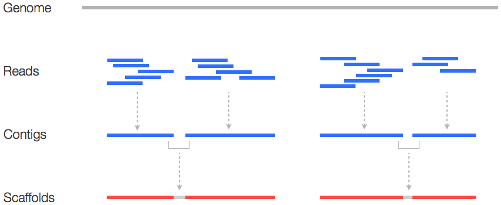

Figure 1: Reads versus contigs versus scaffolds (Vijay Lakhujani))

### 1.2.2 From short reads to contigs: how do we assemble bacterial genomes?

The goal of genome assembly is to take thousands, millions, or even billions of short Illumina reads and obtain contigs, or continuous, closed stretches of DNA. Sounds easy, right?

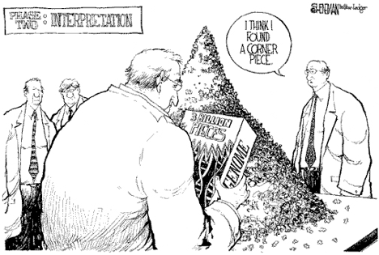

Figure 2: Genome assembly is easy, right? (BioBeans)

We can tackle this problem by breaking it into pieces…literally, by using De Bruijn graphs. De Bruijn graphs are a type of directed graph. A directed graph is a structure made up of a set of vertices connected by edges, where the edges have direction:

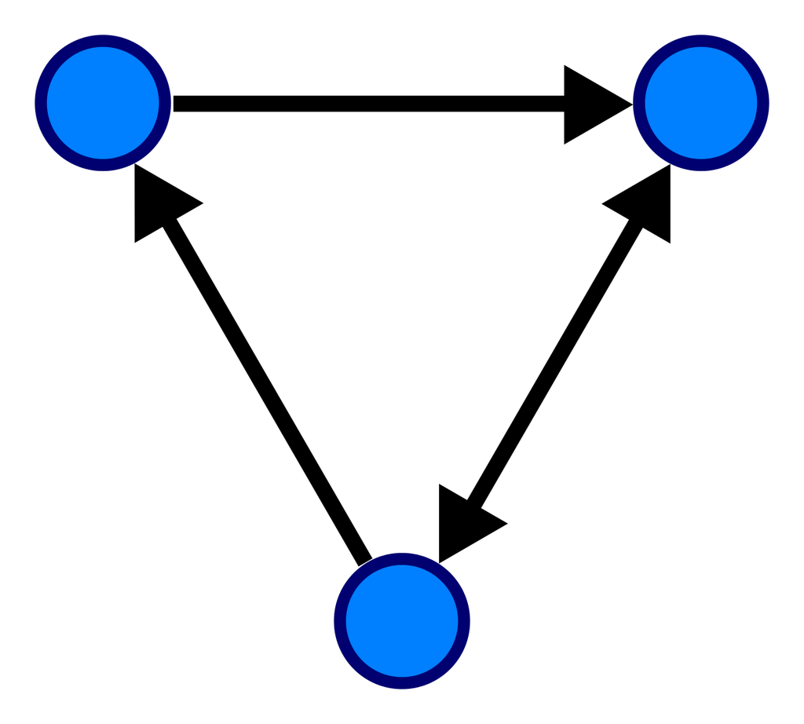

Figure 3: A simple directed graph (Wikipedia)

A De Bruijn graph is a directed graph which represents overlaps between sequences of symbols. Sequences can be reconstructed by moving between nodes in the graph. In the context of reconstructing a genome from Illumina data, the nodes are k-mers, or all possible sub-sequences of length k that are contained in a sequence. For example, if we wanted to find all 3-mers in a sequence of characters, “Salmonella”, we would have the following:

“Sal”, “alm”, “lmo”, “mon”, “one”, “nel”, “ell”, “lla”

Our k-mers will have k-1 overlap (in our case, k-1 = 3-1 = 2). Starting with “Sal”, we need the next 3-mer to begin with “a”, followed by “l”. So our next 3-mer is “alm”:

Sal  
alm

The third 3-mer needs to begin with “lm”, so it must be “lmo”:

Sal  
alm  
lmo

And the rest follow:

Sal  
alm  
lmo  
mon  
one  
nel  
ell  
lla

Another example:

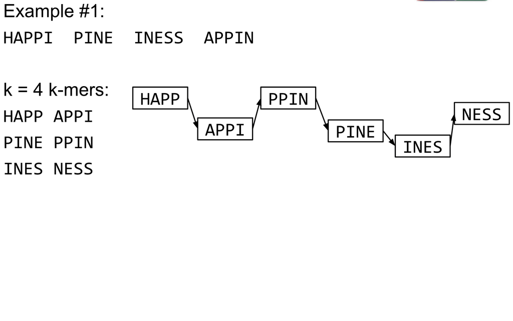

Figure 4: Assembling “happiness” with 4-mers (Galaxy)

Another example, this time with a DNA sequence, k = 7, and overlap of 7-1 = 6 nucleotides:

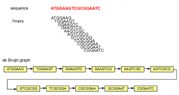

Figure 5: Assembling a nucleotide sequence with 7-mers (homolog.us)

These are obviously some very simple examples. You can probably imagine how this can get complicated pretty quickly:

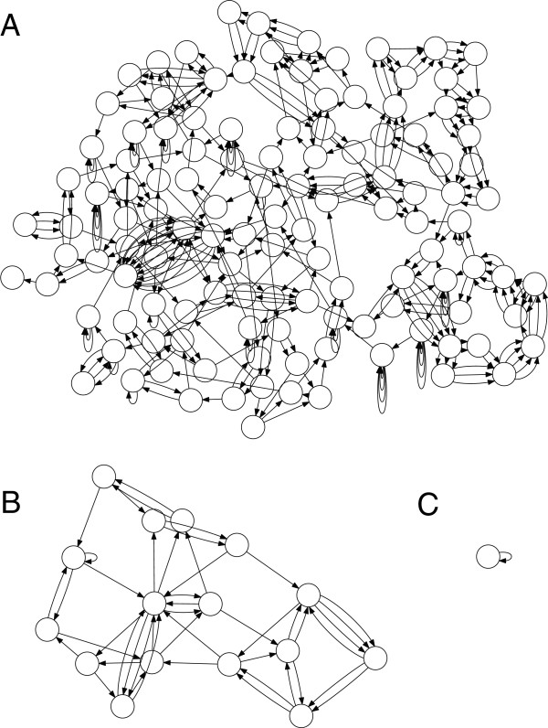

Figure 6: de Bruijn graphs for E. coli K12 where k = 50 (A), k = 1,000 (B), and k = 5,000 (C). (Koren, et al., 2013, Genome Biology)

Luckily, several assemblers that can be used to asseble bacterial genomes from multicell (i.e., not single-cell) data exist. However, SPAdes has become one of the most popular in recent years due to the [improvments it made relative to its predecessors](https://www.ncbi.nlm.nih.gov/pmc/articles/PMC3342519/) (click [here](http://cab.spbu.ru/software/spades/) for some more benchmarking fun). Very recently, however, [SKESA](https://genomebiology.biomedcentral.com/articles/10.1186/s13059-018-1540-z), the assembler used to assemble hundreds of thousands of genomes in NCBI’s Sequence Read Archive (SRA) database, has been made available. There is [some debate](http://cab.spbu.ru/benchmarking-tools-for-de-novo-microbial-assembly/) as to which assembler is best for assembling the genomes of bacterial isolates; however, for this workshop, we will be using SPAdes with our trimmed read pairs (trimmed using Trimmomatic), taking advantage of SPAde’s internal mismatch correction option, which [has been shown to perform well for assembling bacterial isolates.](http://cab.spbu.ru/benchmarking-tools-for-de-novo-microbial-assembly/)

### 1.2.3 What makes a good genome assembly?

There are numerous metrics that can be used to assess genome quality, including:

Genome size

Number of contigs

Length of longest contig

N50 (the sequence length of the shortest contig at 50% of the total genome length)

L50 (the smallest number of contigs whose length sum makes up half of genome size)

Distribution of contigs with various lengths (e.g., how many contigs are longer than 1,000 bp? 5,000 bp?)

Number of ambiguous bases (Ns) present in the assembly

Average per-base-pair read coverage

Conveniently, [QUAST](http://quast.sourceforge.net/quast) is able to report many of these metrics for us; as such, we’ll be using it to evaluate the assembled genome of our mystery *Salmonella* isolate.

### 1.2.4 Doing the t-most with tmux

So far, all of the software we have run has taken relatively fast to run to completion (i.e., just a few minutes). But what if we had to run an analysis that took hours, days, or even weeks to finish? If we lost our connection to the remote host, the analysis could terminate! Luckily, we can use a **terminal multiplexer**, which is software which will allow our session to remain active, even when we’re not logged into the remote host. Popular terminal multiplexers available for Unix-like systems include [GNU Screen](https://www.gnu.org/software/screen/) and tmux, the latter of which we will be using today when we assemble a genome. By assembling a genome in a tmux session, we will be able to work on other things (and even exit our terminal!) while we wait for it to finish.

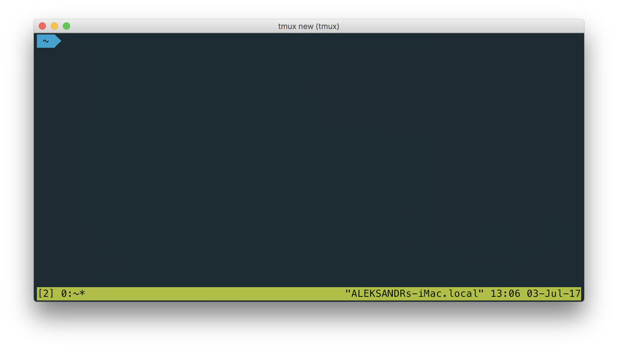

Figure 7: The default view after starting new tmux session (Alek Shnayder)

# 2 Activity 1.2

## 2.1 Getting the hang of tmux

1. After accessing the remote workstation (see Activity 1.1, Section 2.1 for a refresher), we can initiate a new `tmux` session by running the following command:

```
tmux
```

Simple!

2. Whenever we want to detach from a session (say, we’re running an analysis that will take quite some time, and we want to log out of our computer and grab a coffee), we detach our current session by holding the `ctrl` and `b` keys at the same time, releasing, and then pressing the `d` key (no need to hit enter! It will detach when you press `d`). Practice detaching your tmux session now.

You should now be back to your normal shell.

3. Let’s say we want to return to our active tmux session that we just detached (e.g., we’ve returned from our coffee break, and we want to check if our analysis has finished!) We can list all of our active tmux sessions using the following:

```
tmux ls
```

Active tmux sessions will have a number associated with them. Because we only have one session, we will just see a session labeled `0`. To attach with session 0 as our target (`-t`), we can run the following command:

```
tmux attach -t 0
```

We’re back in! Let’s continue in our session, session 0; we want to assemble a genome (which will take some time), and we don’t want to worry about closing our computer and stopping our assembly prematurly.

## 2.2 Assemble a bacterial genome using SPAdes

1. Now that we’re in our tmux session, we can prepare to assemble a genome. Let’s make sure that we are starting from our home directory (`/home/myUsername`, where `myUsername` corresponds to your own username). To do so, `cd` (change directories) to your home directory (remember the `~` shortcut?):

```
cd ~
```

If we type `pwd` to print our current working directory, we should see we are in our home directory:

```
pwd
```

If we type `ls`, we should see that our `activity1` directory is still there:

```
ls
```

(If, for some reason, you accidentally deleted your `activity1` directory, have no fear! Just type `mkdir activity1` to create a new one)

2. To assemble our genome, we are going to want to use our trimmed read pairs that we trimmed using Trimmomatic (the trimmedP.fastq.gz files from Activity 1.1). These should be in our `activity1` directory, so let’s move to our `activity1` directory:

```
cd activity1
```

If we type `ls`, we should see that the file containing our trimmed forward read pairs for our Mystery Salmonella A isolate, `mystery_salmonella_A_trimmedP_1.fastq.gz`, should be among the files in our current working directory (`activity1`), as well as the file containing its trimmed reverse read pairs, `mystery_salmonella_A_trimmedP_2.fastq.gz`:

```
ls
```

(If, for some reason, you accidentally deleted your `activity1` directory, or if you deleted your `trimmedP.fastq.gz` files, you can just copy the backup trimmedP files to your `activity1` directory with the following command: `cp /home/labinstructor/wgs_workshop/activity1_2/*_trimmedP**.fastq.gz .`)

3. Now that we have our forward and reverse trimmed read pairs in gzipped fastq format (`.fastq.gz`), let’s use [SPAdes](http://cab.spbu.ru/software/spades/) to assemble our genome *de novo* (i.e., without a reference genome).

The general format for running SPAdes using paired-end Illumina reads from a bacterial isolate is as follows (note: don’t execute this command; it is just an example):

```
spades.py -k <comma-delimited k-mer lengths> --careful -1 </path/to/isolate_trimmedP_1.fastq.gz> -2 </path/to/isolate_trimmedP_2.fastq.gz> -o </path/to/desired/output_directory> -t <number of threads> -m <memory limit in gigabytes>
```

Let’s go through this command, piece-by-piece:

- **The path to `spades.py` (`spades.py`)**

We need to tell the computer that we want to run SPAdes; we do this by supplying the path to `spades.py`; in our case, we will use `/opt/SPAdes-3.13.0-Linux/bin/spades.py`

- **The list of k-mer sizes to test (`-k`)**

According to the SPAdes manual, we need to supply a “comma-separated list of k-mer sizes to be used (all values must be odd, less than 128 and listed in ascending order)”. As such, we need to know what read length we are working with. According to our FastQC html output files for Mystery Salmonella A, we know this isolate was sequenced with 2x250 bp reads (because they were paired-end reads, and because the “Sequence length” listed by FastQC is 36 [corresponding to our minimum length filter for Trimmomatic] to 250 bp). So, consulting the SPAdes manual, we will use `-k 21,33,55,77,99,127`

- **Reduce the number of mismatches and indels, and run SPAdes MismatchCorrector (`--careful`)**

Adding this option will turn on SPAdes’ internal mismatch correction tool. Remember [this post?](http://cab.spbu.ru/benchmarking-tools-for-de-novo-microbial-assembly/) We will add this option.

- **Supply the path to the fastq.gz file containing trimmed forward read pairs: `-1 </path/to/isolate_trimmedP_1.fastq.gz>`**

In our case, this will just be `-1 mystery_salmonella_A_trimmedP_1.fastq.gz`

- **Supply the path to the fastq.gz file containing trimmed reverse read pairs: `-2 </path/to/isolate_trimmedP_2.fastq.gz>`**

In our case, this is just `-2 mystery_salmonella_A_trimmedP_2.fastq.gz`

- **Supply a path/name to the desired output directory: `-o </path/to/desired/output_directory>`**

You can hypothetically name your output directory anything, but let’s name ours after the isolate we are querying: `-o mystery_salmonella_A`

- **Number of threads to use: `-t <number of threads>`**

This value is specific to the computer on which you’re running SPAdes, as the number of threads you have available will determine this. If we type the following command, we can see this:

```
lscpu | grep -E '^Thread|^Core|^Socket|^CPU\('
```

By default, SPAdes uses `-t 16`, but because several of us will be running SPAdes at once, let’s just use `-t 4`

- **Memory limit in gigabytes: `-m <memory limit in gigabytes>`**

This value is also specific to the computer on which you are running SPAdes, as SPAdes will terminate if it reaches this limit (by default, SPAdes uses `-m 250`). Remember the `free -h` command? We can type that to get some information on our memory usage:

```
free -h
```

As such, let’s use `-m 20`

Now, let’s put it all together by running the following command:

```
/opt/SPAdes-3.13.0-Linux/bin/spades.py -k 21,33,55,77,99,127 --careful -1 mystery_salmonella_A_trimmedP_1.fastq.gz -2 mystery_salmonella_A_trimmedP_2.fastq.gz -o mystery_salmonella_A -t 4 -m 20
```

4. Assembling our genome is going to take some time (~25 minutes or so). To detach our tmux session (and leave SPAdes running while we work on other things), hold the `ctrl` key, hold the `b` key, release both keys, and press the `d` key. You should now be back to your normal shell.

Whenver you want to check in on SPAdes to see what’s happening, you can just attach your tmux session:

```
tmux attach -t 0
```

…and you can always detach by holding the `ctrl` key, holding the `b` key, release both keys, and pressing the `d` key.

## 2.3 Assess the quality of an assembled genome using QUAST

1. Rather than wait for our assembly to complete, we will use precomputed results from SPAdes deposited in a directory named `mystery_salmonella_A_finished`, which is located in the `/home/labinstructor/wgs_workshop/activity1_2/` directory. These results were obtained by running SPAdes using the exact same command that you ran above, with the exact same input files; the only difference is the output directory name (I used `-o mystery_salmonella_A_finished`, instead of `-o mystery_salmonella_A` so we could differentiate them)

Let’s start by making sure that we are starting from our `activity1` directory, which is in our home (`~`) directory. To move to our `activity1` directory, run the following command:

```
cd ~/activity1
```

If we type `pwd`, we should see that we are now in `activity1`:

```
pwd
```

If we type `ls`, we should see that the output directory we created while running SPAdes, `mystery_salmonella_A` is present among the files in `activity1`:

```
ls
```

2. Let’s copy `mystery_salmonella_A_finished`, the directory with the precomputed output from SPAdes, to our `activity1` directory. To do this, we will use `cp`, but this time with the `-r` option, which stands for “recursive”, because we want to copy an entire directory and not just a single file. Similar to before, we specify the path to the directory we want to copy (`/home/labinstructor/wgs_workshop/activity1_2/mystery_salmonella_A_finished`), as well as the path to the destination directory (because we are already in `activity1`, we can just use `.` to signify our current directory):

```
cp -r /home/labinstructor/wgs_workshop/activity1_2/mystery_salmonella_A_finished .
```

If we type `ls`, we should now see a directory called `mystery_salmonella_A_finished` in our current directory:

```
ls
```

3. Let’s move to `mystery_salmonella_A_finished` so that we can take a look at the output that SPAdes produces:

```
cd mystery_salmonella_A_finished
```

If we type `ls`, we should see numerous output files and directories:

```
ls
```

You can read in detail about all of the files which SPAdes outputs in the [SPAdes manual.](http://cab.spbu.ru/files/release3.13.0/manual.html) However, for this workshop, we are interested in the `contigs.fasta` file, which contains our final contigs produced by SPAdes.

4. Now that we have an assembled genome (`contigs.fasta`), let’s use [QUAST](http://bioinf.spbau.ru/quast) to assess the quality of our genome. QUAST provides various metrics which we can use to evaluate the quality of our assembled genome.

The general format for running QUAST to evaluate an assembled genome in fasta format is as follows (note: don’t execute this command; it is just an example):

```
quast.py -o </path/to/desired/output_directory> --min-contig 1 </path/to/input/contigs.fasta>
```

In our case, the path to `quast.py` is `/opt/quast/quast.py`

While QUAST has many options other than this (use `/opt/quast/quast.py -h` to see them all), we will just supply our input assembly (`contigs.fasta`), an output directory (we could name this anything, but let’s call it `mystery_salmonella_A_contigs_quast`), the number of threads (this depends on our computer, but here we will just use `--threads 4`), and we will change the `--min-contig` option to `--min-contig 1` (by default, QUAST sets this parameter to `--min-contig 500`, but we will lower it to 1 to consider all of our contigs in our assembly, not just those over 500 bp in length)

To that end, run QUAST using the following command:

```
/opt/quast/quast.py -o mystery_salmonella_A_contigs_quast --threads 4 --min-contig 1 contigs.fasta
```

5. When QUAST finishes, we can take a look at one of the text files with a summary of our results. If we type `ls` and supply the path to our directory with our QUAST results, `mystery_salmonella_A_contigs_quast`, we’ll see that QUAST has produced numerous reports:

```
ls mystery_salmonella_A_contigs_quast
```

If you want to look at the graphical reports that QUAST produced, you can copy them over to your local computer as described in Section 2.3, Step #4 of Activity 1.1. However, we can quickly view one of the short text-based reports, `report.txt`, using `cat`, which will print the text to our terminal in its entirety:

```
cat mystery_salmonella_A_contigs_quast/report.txt
```

We can see a lot of valuable statistics for our assembled genome, including its N50, L50, total length, longest contig, distribution of contig lengths, and GC content.

# 3 Supplemental Activities

Have extra time? The following Supplemental Readings and Activities are designed to give you extra practice with some of the tools and/or topics covered in this Activity, as well as to introduce some new concepts for participants who want an extra challenge. Feel free to work on all of the activities/readings, or pick your favorite (or, feel free to work on your own projects, or just relax!).

## 3.1 Supplemental Readings

**Topic: high-level overviews of workflows used to analyze microbial NGS data**

Alkema, Wynand, Jos Boekhorst, Michiel Wels, Sacha A.F.T. van Hijum. 2016. [Microbial bioinformatics for food safety and production.](https://www.ncbi.nlm.nih.gov/pmc/articles/PMC4793891/) *Briefings in Bioinformatics* 17(2): 283-292.

Carriço, J.A., M. Rossi, J. Moran-Gilad, G.Van Domselaar, M.Ramirez. 2018. [A primer on microbial bioinformatics for nonbioinformaticians.](https://www.ncbi.nlm.nih.gov/pubmed/29309933) *Clinical Microbiology and Infection* 24(4): 342-349. DOI: https://doi.org/10.1016/j.cmi.2017.12.015.

Sekse, Camilla, Arne Holst-Jensen, Ulrich Dobrindt, Gro S. Johannessen, Weihua Li, Bjørn Spilsberg, Jianxin Shi. 2017. [High Throughput Sequencing for Detection of Foodborne Pathogens.](https://www.ncbi.nlm.nih.gov/pmc/articles/PMC5655695/) *Frontiers in Microbiology* 8: 2029. DOI: 10.3389/fmicb.2017.02029.

## 3.2 Assess the average coverage of an assembled genome using bwa mem and samtools

Let’s start by moving to our `activity1` directory:

```
cd ~/activity1
```

If we type `pwd`, we’ll see we are in `activity1`:

```
pwd
```

If we type `ls`, we should see several files and directories, including our trimmed read pair files (`mystery_salmonella_A_trimmedP_1.fastq.gz` and `mystery_salmonella_A_trimmedP_2.fastq.gz`) and the directory with our precomputed SPAdes output (`mystery_salmonella_A_finished`):

```
ls
```

2. Let’s copy our assembled genome, `contigs.fasta` to the same directory as our trimmed read pairs (our current directory) and name it as `mystery_salmonella_A.fasta` so that we know that this particular assembly was derived from these reads:

```
cp mystery_salmonella_A_finished/contigs.fasta ./mystery_salmonella_A.fasta
```

With this command, we’ve made a copy of `contigs.fasta` in our current directory (`activity1`), which we’ve named `mystery_salmonella_A.fasta`

3. To map our trimmed read pairs back to our assembly with bwa mem, we need bwa to first create an index of the genome to which we want to map our reads (our *de novo* assembly, `mystery_salmonella_A.fasta`). To do this, we call `bwa`, its `index` function, and supply the path to our assembly:

```
bwa index mystery_salmonella_A.fasta
```

4. Now we can map our trimmed reads to our assembly using bwa mem; we will call `bwa mem`, supply the paths to our indexed assembled genome, our forward reads, and our reverse reads, and save the output to a sam file called `mystery_salmonella_A.sam` (a sam file is just a special format for alignment data. We will learn all about sam files in the next lecture):

```
bwa mem mystery_salmonella_A.fasta mystery_salmonella_A_trimmedP_1.fastq.gz mystery_salmonella_A_trimmedP_2.fastq.gz > mystery_salmonella_A.sam
```

5. Once this is finished (it will take a few minutes), we will convert our sam file to a bam file (just the binary version of a sam file) using the `-b` option with the `view` command in samtools, a toolkit for manipulating genomic data in different formats. We will save our bam file as `mystery_salmonella_A.bam`:

```
samtools view -b mystery_salmonella_A.sam > mystery_salmonella_A.bam
```

6. Now, we will use samtools to sort our bam alignment by its leftmost coordinates (like indexing, sorting is just a processing step that many downstream analyses using samtools require). We will save this sorted bam file as `mystery_salmonella_A_sorted.bam`:

```
samtools sort mystery_salmonella_A.bam -o mystery_salmonella_A_sorted.bam
```

7. We will use samtools to index our sorted bam file (another processing step):

```
samtools index mystery_salmonella_A_sorted.bam
```

8. And now, finally, we can calculate the average per-base coverage for our genome! We will use the following command:

```
X=$(samtools depth mystery_salmonella_A_sorted.bam | awk '{sum+=$3} END { print sum/NR}')
```

Confused? Don’t worry; all we are doing in this command is the following:

- Calling the `samtools depth` command, which computes the depth at each position in the genome (i.e., the number of reads mapped to each position in the genome). This information is contained in our sorted bam file, `mystery_salmonella_A_sorted.bam`
- We are piping this output (`|`) to `awk`, which is taking the average of the third column.
- This final value, our average coverage value, is stored as a variable, `X`
9. And, finally, we can print our variable X (our average coverage) using `echo`:

```
echo "$X"
```

# 4 References

Bankevich, Anton, et al. 2012. [SPAdes: A New Genome Assembly Algorithm and Its Applications to Single-Cell Sequencing.](https://www.ncbi.nlm.nih.gov/pmc/articles/PMC3342519/) *Journal of Computational Biology* 19(5): 455–477.

Gurevich, Alexey, et al. 2013. [QUAST: quality assessment tool for genome assemblies.](https://www.ncbi.nlm.nih.gov/pmc/articles/PMC3624806/) *Bioinformatics* 29(8): 1072–1075.

JGI. “What is a Scaffold?” Accessed April 15, 2019. URL: https://genome.jgi.doe.gov/help/scaffolds.jsf.

Koren, S., et al. 2013. [Reducing assembly complexity of microbial genomes with single-molecule sequencing.](https://www.ncbi.nlm.nih.gov/pmc/articles/PMC4053942/) *Genome Biology* 14(9):R101.

PacBio Blog. September 21, 2016. “Genomes vs. GenNNNes: The Difference between Contigs and Scaffolds in Genome Assemblies”. Accessed April 15, 2019. URL: https://www.pacb.com/blog/genomes-vs-gennnnes-difference-contigs-scaffolds-genome-assemblies/